# Birthday

Dan MacKinnon

March 15, 2017

## Introduction

The Birthday Problem, as frequently happens in questions of probability, is easy to state and understand, yet leads to an (initially) suprising solution.

> In a group of *n* people, how likely is it to find two or more people sharing the same birthday?

Many people are surprised to find out that in a group of 23 people, there is just over a fifty percent chance of finding a birthday match, and in a group of 60 people, you are almost certain to find two or more people sharing a birthday.

## Direct Calculation

If $B_n$ is the event that we find two or more people in a group of $n$ that share a birthday, then $\neg B_n$, is the probability that there are no birthday matches in a group of $n$ people, and the probability of this event is a bit easier to calculate.

In a group of one, $n = 1$, there is no chance to find two or more people that share a birthday. In a group of two, the probabability of not sharing a birthday is $p(\neg B_2) = \frac{364}{365}$. For a group of three, we have $p(\neg B_2) = \frac{364}{365} \times \frac{363}{365}$, and in general:

$$p(\neg B_n) = \prod_{i=1}^n \frac{366-i}{365}$$

We can set up a data frame **BCalc** in R to calculate this directly.

```r
group_size <- 60
group <- 1:group_size
BCalc <- data.frame(group)
BCalc$noMatch[1] = 1;
for (i in 2:group_size) {
  BCalc$noMatch[i] <- BCalc$noMatch[i-1]*(366-i)/365
}
BCalc$match <- 1 - BCalc$noMatch
```

Plotting this relationship between the probability of a birthday match and the size of the group involved gives a characteristic sigmoid or logistic curve.

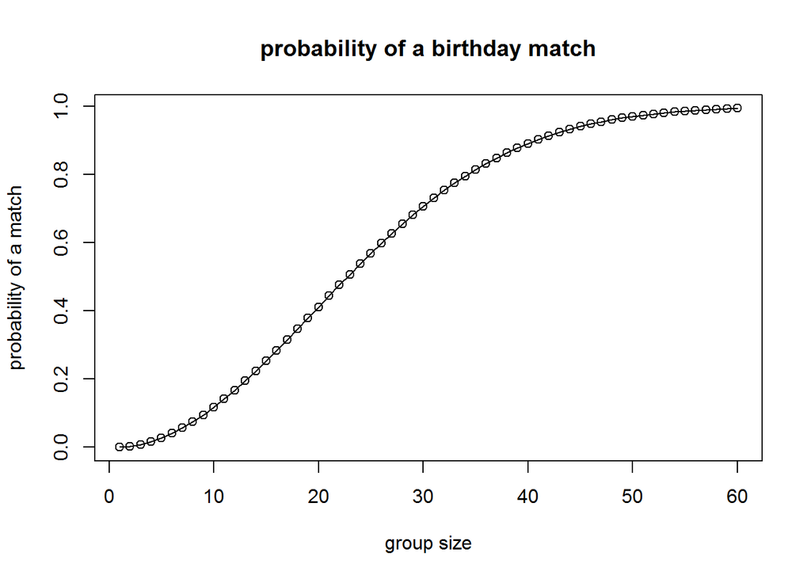

```r
plot(BCalc$group, BCalc$match,main='probability of a birthday match', xlab = 'group size', ylab='probability of a match')
lines(BCalc$group, BCalc$match)
```

This gives the somewhat surprising result that, in a group of 23 people there is over a fifity percent chance of finding two people with the same birthday.

```r
BCalc$match[23]
```

```
## [1] 0.5072972
```

By the time you have sixty people together, it is almost a sure thing to find a match.

```r
BCalc$match[60]
```

```
## [1] 0.9941227
```

## Setting up the Simulation

A simulation can be set up by randomly generating groups of numbers between 1 and 365, and checking to see if there are matches. For each group size between 1 and 60, we’ll generate 100 groups and check for collisions, the results will be cases in the **BSim** data frame.

```r
group_size <- 60
trial_limit <-100
trial_index <- 1:(group_size * trial_limit)
BSim <- data.frame(trial_index)
current_index <- 1;
for (i in 1:group_size) {
  for (k in 1:trial_limit) {
    t <- sample(1:365, i, replace=TRUE)
    BSim$groupSize[current_index] <- i
    BSim$foundMatch[current_index] <- as.logical(anyDuplicated(t))
    current_index <- current_index +1
  }
}
```

## Exploring the Simulation

For each group size, we can find the proportion of groups that contained a match, and plot the results in comparison to the expected curve from the **BCalc** data frame.

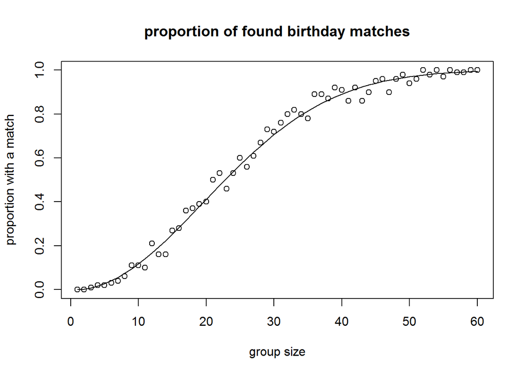

```r
tbl <- table(BSim$groupSize,BSim$foundMatch)
mtrx <- as.matrix(prop.table(tbl,1)[,2])
plot(1:group_size, mtrx[,1],main='proportion of found birthday matches', xlab = 'group size', ylab='proportion with a match')
lines(BCalc$group, BCalc$match)
```